**NOTE:** I uploaded the CSV files from the drive. I am also submitting my CSV files. Please, If you would like to run the code. Download the CSV file, which I submitted and give the path and run the cell. Sorry for inconvience.

# **Project Title: Book Rating Prediction & Recommender System**

**Project Overview**

**Data Set Title:** Goodreads-Books

**URL:** https://www.kaggle.com/jealousleopard/goodreadsbooks

**Description:** I would like to develop a Machine Learning data model on the Kaggle Dataset “Goodreads-Books” (“https://www.kaggle.com/jealousleopard/goodreadsbooks”). Here I aim to develop a book rating prediction model and evaluate the model with necessary metrics.

**Introduction:** Goodreads is a social cataloging website which allows users to search books, annotations, and reviews. Ratings play a vital role for users in selection process.

## **Problem Statement:**

As rating will faciliate to identity best books, I aim to predict average rating for books. This will facilitate a quick glance on top rated books.

**Data Set Information:** The data set contains few features about books with which book rating could be predicted.

**Columns data:**

1. bookID: A unique Identification number for each book.
2. Title: The name under which the book was published.
3. Authors: Names of the authors of the book. Multiple authors are delimited with -.
4. average_rating: The average rating of the book received in total.
5. Isbn: Another unique number to identify the book, the International Standard Book Number.
6. isbn13: A 13-digit ISBN to identify the book, instead of the standard 11-digit ISBN.
7. language_code: Helps understand what is the primary language of the book. For instance, eng is standard for English.
8. No of num_pages: Number of pages the book contains.
9. ratings_count: Total number of ratings the book received.
10. text_reviews_count: Total number of written text reviews the book received.

**End Goal:** To develop a book rating prediction model and evaluate the model with necessary metrics, build a recommender system.

**Process:** I would like to perform the follow steps in the process as follows:

1. Data collection
2. Data cleaning and preprocessing
3. Exploratory Data Analysis (EDA)
4. Data visualization
5. Data Modelling
6. Model Evaluation

Firstly I begin with data collection and understand prominently the features and its basic information such as type. Based on the columns I would check if there is any possibility to preprocess the data and perform data cleaning. I would imply exploratory data techniques and get analysis of feature correlation with target features. I would use different plots such as box plot, scatter plot, line plots, histograms, bar charts as necessary to perform Data visualization for data analysis. Based on the analysis, I aim to develop a Machine Learning model which will predict the average rating of books.

**Secodary data set:** https://www.kaggle.com/zygmunt/goodbooks-10k Data set contains 5 files as follows which contains ratings for ten thousand popular books.

1. Book_tags.csv ( 3 columns ) : This contains tags assigned by users to books.
2. Books.csv ( 3 columns ) : This contain meta data of books.
3. Ratings.csv ( 3 columns ) : This contains ratings information.
4. Tags.csv ( 3 columns ) : This contains names which are translated from tag ID.
5. To_read.csv ( 3 columns ) : This contains IDs of books marked “to_read” by each user.

Using, these files I would like build a recommendation system on the data by relevant techniques as per data analysis and evaluate the model.

# **Primary Data Set: Prediction System**

# STEP 1 - DATA COLLECTION

```python
#libraries
import numpy as np
import pandas as pd
import io
import seaborn as sns
from matplotlib import mlab
import matplotlib.pyplot as plt
from wordcloud import WordCloud
from sklearn.model_selection import train_test_split
from sklearn import datasets, linear_model
from sklearn import preprocessing
from sklearn.metrics import mean_squared_error, r2_score
from sklearn.feature_extraction.text import TfidfVectorizer
from sklearn.metrics.pairwise import linear_kernel
from sklearn.metrics.pairwise import cosine_similarity
from sklearn.metrics import mean_absolute_error
```

```python
from google.colab import drive
drive.mount('/content/gdrive')
```

```python
data=pd.read_csv('gdrive/My Drive/dspproject/books.csv')
#view data
data.head()
```

|  | bookID | title | authors | average_rating | isbn | isbn13 | language_code | # num_pages | ratings_count | text_reviews_count |
| --- | --- | --- | --- | --- | --- | --- | --- | --- | --- | --- |
| 0 | 1 | Harry Potter and the Half-Blood Prince (Harry ... | J.K. Rowling-Mary GrandPré | 4.56 | 0439785960 | 9780439785969 | eng | 652 | 1944099 | 26249 |
| 1 | 2 | Harry Potter and the Order of the Phoenix (Har... | J.K. Rowling-Mary GrandPré | 4.49 | 0439358078 | 9780439358071 | eng | 870 | 1996446 | 27613 |
| 2 | 3 | Harry Potter and the Sorcerer's Stone (Harry P... | J.K. Rowling-Mary GrandPré | 4.47 | 0439554934 | 9780439554930 | eng | 320 | 5629932 | 70390 |
| 3 | 4 | Harry Potter and the Chamber of Secrets (Harry... | J.K. Rowling | 4.41 | 0439554896 | 9780439554893 | eng | 352 | 6267 | 272 |
| 4 | 5 | Harry Potter and the Prisoner of Azkaban (Harr... | J.K. Rowling-Mary GrandPré | 4.55 | 043965548X | 9780439655484 | eng | 435 | 2149872 | 33964 |

```python
#No of rows , No of columns
print("No of rows , No of columns :",data.shape)
```

```
No of rows , No of columns : (3500, 10)
```

```python
data.info()
```

```
<class 'pandas.core.frame.DataFrame'>
RangeIndex: 3500 entries, 0 to 3499
Data columns (total 10 columns):
 #   Column              Non-Null Count  Dtype
---  ------              --------------  -----
 0   bookID              3500 non-null   int64
 1   title               3500 non-null   object
 2   authors             3500 non-null   object
 3   average_rating      3500 non-null   float64
 4   isbn                3500 non-null   object
 5   isbn13              3500 non-null   int64
 6   language_code       3500 non-null   object
 7   # num_pages         3500 non-null   int64
 8   ratings_count       3500 non-null   int64
 9   text_reviews_count  3500 non-null   int64
dtypes: float64(1), int64(5), object(4)
memory usage: 273.6+ KB
```

```python
data.describe()
```

|  | bookID | average_rating | isbn13 | # num_pages | ratings_count | text_reviews_count |
| --- | --- | --- | --- | --- | --- | --- |
| count | 3500.000000 | 3500.000000 | 3.500000e+03 | 3500.000000 | 3.500000e+03 | 3500.000000 |
| mean | 5291.483429 | 3.940549 | 9.762017e+12 | 347.397143 | 3.415949e+04 | 918.740571 |
| std | 3169.548935 | 0.326962 | 4.223434e+11 | 249.606846 | 1.784897e+05 | 3445.968337 |
| min | 1.000000 | 0.000000 | 8.987060e+09 | 0.000000 | 0.000000e+00 | 0.000000 |
| 25% | 2548.500000 | 3.770000 | 9.780317e+12 | 198.000000 | 1.110000e+02 | 10.000000 |
| 50% | 5179.500000 | 3.960000 | 9.780522e+12 | 301.000000 | 9.455000e+02 | 66.000000 |
| 75% | 7911.750000 | 4.130000 | 9.780822e+12 | 432.000000 | 7.807500e+03 | 369.500000 |
| max | 10853.000000 | 5.000000 | 9.789991e+12 | 3342.000000 | 5.629932e+06 | 70390.000000 |

```python
data.isnull()
```

|  | bookID | title | authors | average_rating | isbn | isbn13 | language_code | # num_pages | ratings_count | text_reviews_count |
| --- | --- | --- | --- | --- | --- | --- | --- | --- | --- | --- |
| 0 | False | False | False | False | False | False | False | False | False | False |
| 1 | False | False | False | False | False | False | False | False | False | False |
| 2 | False | False | False | False | False | False | False | False | False | False |
| 3 | False | False | False | False | False | False | False | False | False | False |
| 4 | False | False | False | False | False | False | False | False | False | False |
| ... | ... | ... | ... | ... | ... | ... | ... | ... | ... | ... |
| 3495 | False | False | False | False | False | False | False | False | False | False |
| 3496 | False | False | False | False | False | False | False | False | False | False |
| 3497 | False | False | False | False | False | False | False | False | False | False |
| 3498 | False | False | False | False | False | False | False | False | False | False |
| 3499 | False | False | False | False | False | False | False | False | False | False |

3500 rows × 10 columns

```python
data.isnull().any()
```

```
bookID                False
title                 False
authors               False
average_rating        False
isbn                  False
isbn13                False
language_code         False
# num_pages           False
ratings_count         False
text_reviews_count    False
dtype: bool
```

# STEP 2 - DATA PREPROCESSING

```python
#rename column name
data=data.rename(columns={"# num_pages": "num_pages"})
```

```python
data.head()
```

|  | bookID | title | authors | average_rating | isbn | isbn13 | language_code | num_pages | ratings_count | text_reviews_count |
| --- | --- | --- | --- | --- | --- | --- | --- | --- | --- | --- |
| 0 | 1 | Harry Potter and the Half-Blood Prince (Harry ... | J.K. Rowling-Mary GrandPré | 4.56 | 0439785960 | 9780439785969 | eng | 652 | 1944099 | 26249 |
| 1 | 2 | Harry Potter and the Order of the Phoenix (Har... | J.K. Rowling-Mary GrandPré | 4.49 | 0439358078 | 9780439358071 | eng | 870 | 1996446 | 27613 |
| 2 | 3 | Harry Potter and the Sorcerer's Stone (Harry P... | J.K. Rowling-Mary GrandPré | 4.47 | 0439554934 | 9780439554930 | eng | 320 | 5629932 | 70390 |
| 3 | 4 | Harry Potter and the Chamber of Secrets (Harry... | J.K. Rowling | 4.41 | 0439554896 | 9780439554893 | eng | 352 | 6267 | 272 |
| 4 | 5 | Harry Potter and the Prisoner of Azkaban (Harr... | J.K. Rowling-Mary GrandPré | 4.55 | 043965548X | 9780439655484 | eng | 435 | 2149872 | 33964 |

# STEP 3 - EXPLORATORY DATA ANALYSIS

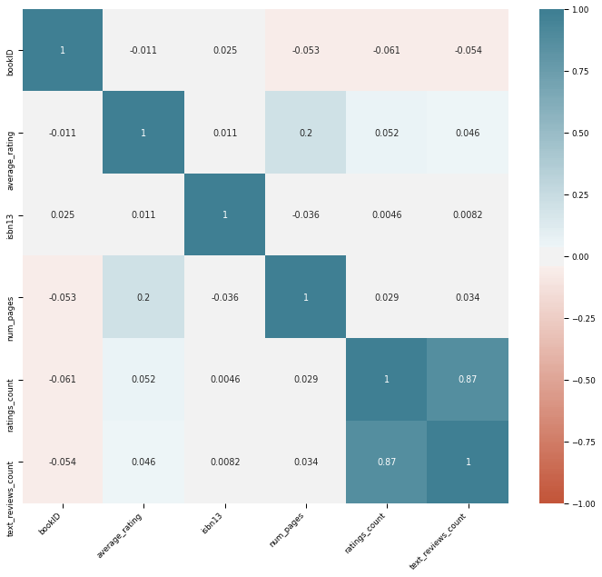

```python
#correlation
plt.figure(figsize=(12, 10))
corr = data.corr()
corr=corr.fillna(0)
ax = sns.heatmap(
    data.corr(),
    vmin=-1, vmax=1, center=0,
    cmap=sns.diverging_palette(20, 220, n=200),
    annot=True
)
ax.set_xticklabels(
    ax.get_xticklabels(),
    rotation=45,
    horizontalalignment='right'
);
```

Here average rating is more correlated to num_pages

```
 Range of average_rating :  $ 0.0  -  $ 5.0
```

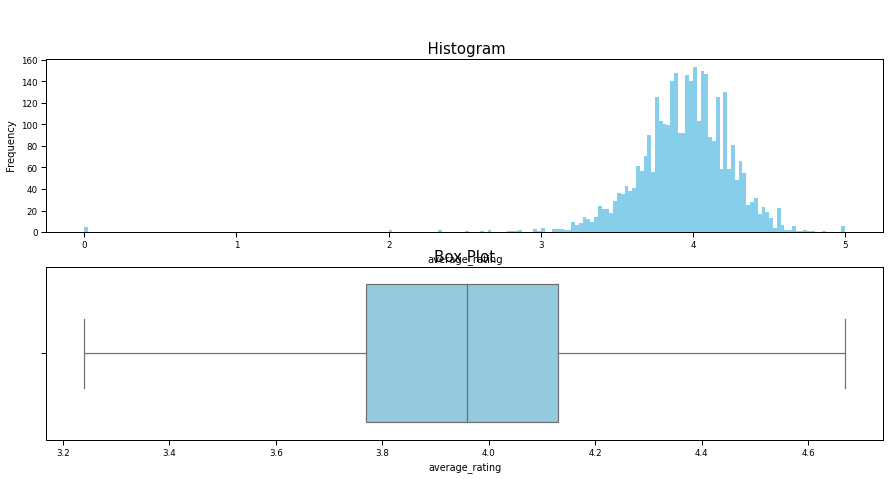

```python
# average_rating column data analysis
print(" Range of average_rating : ",'$',data["average_rating"].min(), ' - ','$',data["average_rating"].max())
fig, ax = plt.subplots(2, 1, figsize = (15, 7))
ax[0].hist(data.average_rating, bins = 200, range = [min(data.average_rating), max(data.average_rating)], label = "average_rating",color = "skyblue")
ax[0].set_title("\n \n  Histogram ", fontsize = 15)
ax[0].set_xlabel("average_rating", fontsize = 10)
ax[0].set_ylabel(" Frequency ", fontsize = 10)
sns.boxplot(data.average_rating, showfliers = False, ax = ax[1],color = "skyblue")

ax[1].set_title("Box Plot", fontsize = 15)
plt.show()
```

Major concentration of average rating is around 3.8 to 4.1

```
 Range of ratings_count :  $ 0  -  $ 70390
```

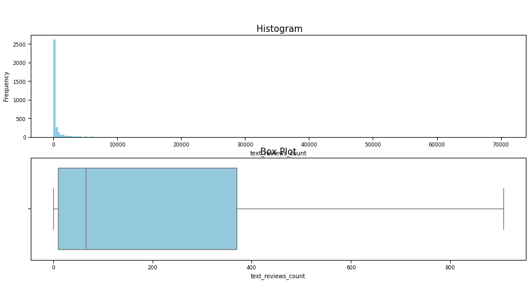

```python
# ratings_count coulmn data analysis
print(" Range of ratings_count : ",'$',data["text_reviews_count"].min(), ' - ','$',data["text_reviews_count"].max())
fig, ax = plt.subplots(2, 1, figsize = (15, 7))
ax[0].hist(data.text_reviews_count, bins = 200, range = [min(data.text_reviews_count), max(data.text_reviews_count)], label = "text_reviews_count",color = "skyblue")
ax[0].set_title("\n \n  Histogram ", fontsize = 15)
ax[0].set_xlabel("text_reviews_count", fontsize = 10)
ax[0].set_ylabel(" Frequency ", fontsize = 10)
sns.boxplot(data.text_reviews_count, showfliers = False, ax = ax[1],color = "skyblue")
ax[1].set_title("Box Plot", fontsize = 15)
plt.show()
```

The Text review count is distributed untill **350**

```python
data.head()
```

|  | bookID | title | authors | average_rating | isbn | isbn13 | language_code | num_pages | ratings_count | text_reviews_count |
| --- | --- | --- | --- | --- | --- | --- | --- | --- | --- | --- |
| 0 | 1 | Harry Potter and the Half-Blood Prince (Harry ... | J.K. Rowling-Mary GrandPré | 4.56 | 0439785960 | 9780439785969 | eng | 652 | 1944099 | 26249 |
| 1 | 2 | Harry Potter and the Order of the Phoenix (Har... | J.K. Rowling-Mary GrandPré | 4.49 | 0439358078 | 9780439358071 | eng | 870 | 1996446 | 27613 |
| 2 | 3 | Harry Potter and the Sorcerer's Stone (Harry P... | J.K. Rowling-Mary GrandPré | 4.47 | 0439554934 | 9780439554930 | eng | 320 | 5629932 | 70390 |
| 3 | 4 | Harry Potter and the Chamber of Secrets (Harry... | J.K. Rowling | 4.41 | 0439554896 | 9780439554893 | eng | 352 | 6267 | 272 |
| 4 | 5 | Harry Potter and the Prisoner of Azkaban (Harr... | J.K. Rowling-Mary GrandPré | 4.55 | 043965548X | 9780439655484 | eng | 435 | 2149872 | 33964 |

```python
#view all columns
print("data",data.columns)
print("\n data.title.unique()",data.title.unique())
print("\n data['title'].size",data['title'].size)
print("\n data['title'].count()",data['title'].count())
print("\n data['title'].nunique()",data['title'].nunique())
print("\n data.authors.unique()",data.authors.unique())
print("\n data['authors'].size",data['authors'].size)
print("\n data['authors'].nunique()",data['authors'].nunique())
print("\n data['average_rating'].nunique()",data['average_rating'].nunique())
print("\n data['language_code'].nunique()",data['language_code'].nunique())
```

```
data Index(['bookID', 'title', 'authors', 'average_rating', 'isbn', 'isbn13',
       'language_code', 'num_pages', 'ratings_count', 'text_reviews_count'],
      dtype='object')

 data.title.unique() ['Harry Potter and the Half-Blood Prince (Harry Potter  #6)'
 'Harry Potter and the Order of the Phoenix (Harry Potter  #5)'
 "Harry Potter and the Sorcerer's Stone (Harry Potter  #1)" ...
 "Gatsby's Girl" 'Into Thin Air: Personal Account of the Everest Disaster'
 "In Search of Captain Zero: A Surfer's Road Trip Beyond the End of the Road"]

 data['title'].size 3500

 data['title'].count() 3500

 data['title'].nunique() 3147

 data.authors.unique() ['J.K. Rowling-Mary GrandPré' 'J.K. Rowling' 'W. Frederick Zimmerman' ...
 'Jon Lee Anderson' 'Caroline Preston' 'Allan C. Weisbecker']

 data['authors'].size 3500

 data['authors'].nunique() 2166

 data['average_rating'].nunique() 173

 data['language_code'].nunique() 20
```

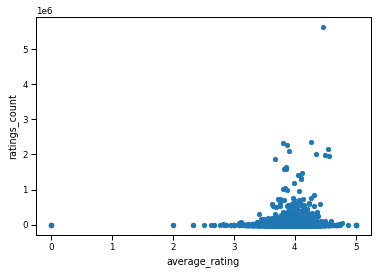

```python
# average_rating and ratings_count relation
ax2 = data.plot.scatter(x='average_rating', y='ratings_count')
```

Focused on average rating around 4 to rating count below 2000000

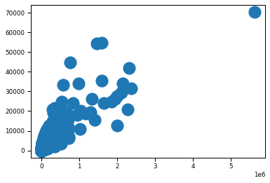

```python
#ratings_count and text_reviews_count relation
plt.scatter(data.ratings_count, data.text_reviews_count, s=300)
```

The average rating is distributed over below 100000 rating count and 20000 text review count

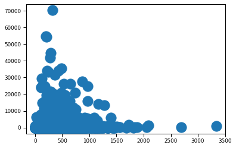

```python
#num_pages and text_reviews_count relation
plt.scatter(data.num_pages, data.text_reviews_count, s=300)
```

The average rating is around 500 num of pages and 20000 text review count

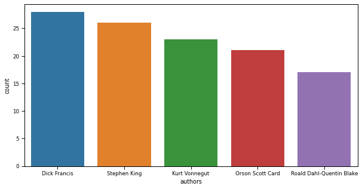

```python
#top 5 authors
plt.figure(figsize=(10,5))
ax=sns.countplot(x = "authors", order=data['authors'].value_counts().index[0:5] ,data=data)
```

```
Unique authors : 2166
```

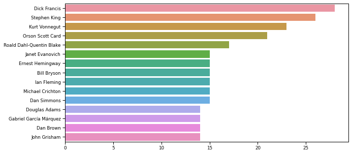

```python
#top 15 authors
plt.figure(figsize=(10,5))
authors = data["authors"].value_counts()
print("Unique authors :", authors.size)
ax=sns.barplot(authors[0:15].values, authors[0:15].index)
```

From the above plot Dick Francis has the most number of books in the list.

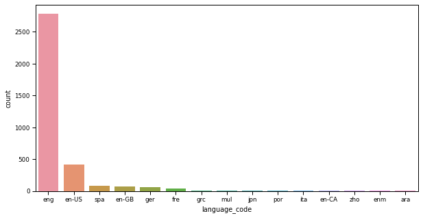

```python
#top language code
plt.figure(figsize=(10,5))
ax=sns.countplot(x = "language_code", order=data['language_code'].value_counts().index[0:15] ,data=data)
```

```
Unique language_code : 20
```

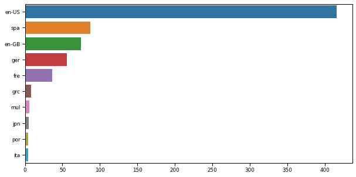

```python
#top unique language code
plt.figure(figsize=(10,5))
language_code = data["language_code"].value_counts()
print("Unique language_code :", language_code.size)
ax=sns.barplot(language_code[1:11].values, language_code[1:11].index)
```

Majority of the books are in english languages, with some further categorised into English-US, english-UK and english-CA.

```
Unique title : 3147
```

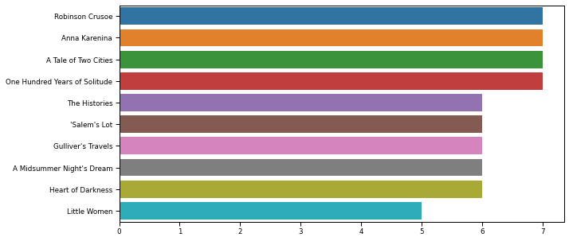

```python
#top unique title
plt.figure(figsize=(10,5))
title = data["title"].value_counts()
print("Unique title :", title.size)
ax= sns.barplot(title[1:11].values, title[1:11].index)
```

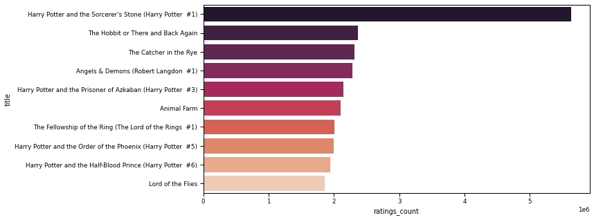

```python
#top 10 most rated books
most_rated = data.sort_values('ratings_count', ascending = False).head(10).set_index('title')
plt.figure(figsize=(10,5))
sns.barplot(most_rated['ratings_count'], most_rated.index, palette='rocket')
```

We can see that the beginning books of the series usually have most of the ratings

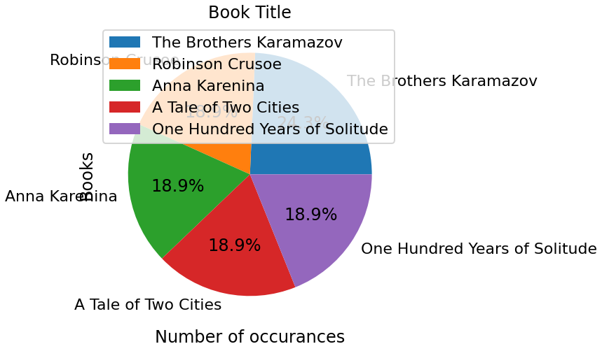

```python
#Which are the books with most occurances in the list?
sns.set_context('poster')
plt.figure(figsize=(10,5))
books = data['title'].value_counts()[:20]
rating = data.average_rating[:20]
data['title'].value_counts().head(5).plot(kind = 'pie', autopct='%1.1f%%', figsize=(8, 8)).legend()
# sns.barplot(x = books, y = books.index)
plt.title("Book Title")
plt.xlabel("Number of occurances")
plt.ylabel("Books")
plt.show()
```

We can see that Brothers Karamazov have the most number of occurrances with the same name in the data.

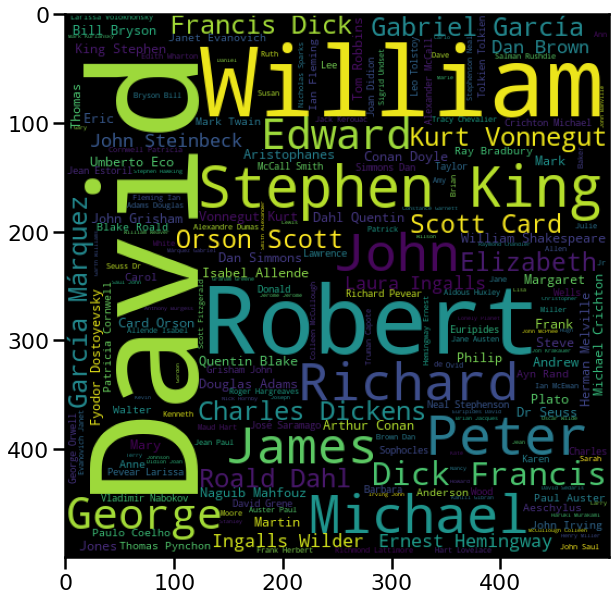

```python
#analysis:
wordcloud = WordCloud(width = 500, height = 500).generate(" ".join(data.authors.astype(str)))
plt.figure(figsize = (15, 10))
plt.imshow(wordcloud)
plt.show()
```

William and David is most frequently repeated.

```python
data.head()
```

|  | bookID | title | authors | average_rating | isbn | isbn13 | language_code | num_pages | ratings_count | text_reviews_count |
| --- | --- | --- | --- | --- | --- | --- | --- | --- | --- | --- |
| 0 | 1 | Harry Potter and the Half-Blood Prince (Harry ... | J.K. Rowling-Mary GrandPré | 4.56 | 0439785960 | 9780439785969 | eng | 652 | 1944099 | 26249 |
| 1 | 2 | Harry Potter and the Order of the Phoenix (Har... | J.K. Rowling-Mary GrandPré | 4.49 | 0439358078 | 9780439358071 | eng | 870 | 1996446 | 27613 |
| 2 | 3 | Harry Potter and the Sorcerer's Stone (Harry P... | J.K. Rowling-Mary GrandPré | 4.47 | 0439554934 | 9780439554930 | eng | 320 | 5629932 | 70390 |
| 3 | 4 | Harry Potter and the Chamber of Secrets (Harry... | J.K. Rowling | 4.41 | 0439554896 | 9780439554893 | eng | 352 | 6267 | 272 |
| 4 | 5 | Harry Potter and the Prisoner of Azkaban (Harr... | J.K. Rowling-Mary GrandPré | 4.55 | 043965548X | 9780439655484 | eng | 435 | 2149872 | 33964 |

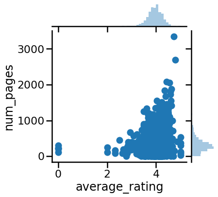

```python
fig=sns.jointplot(x = 'average_rating', y = 'num_pages', data = data, kind='scatter')
```

This plot doesn't give that much of an accurate inference due to the massive presence of outliers for books above 1000 pages, for the maximum density is between 0-1000 pages.

```python
trial = data[~(data['num_pages']>1000)]
```

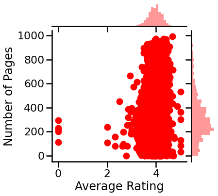

```python
ax = sns.jointplot(x="average_rating", y="num_pages", data = trial, color = 'red')
ax.set_axis_labels("Average Rating", "Number of Pages")
```

From the given plot, we can infer that the highest ratings ever given, usually are for books with the page range of 200-400, peaking near 250. It could lead to the fact that most of the people seem to prefer books with a moderate amount of pages, and that thicker books seems to scare people away.

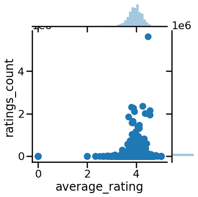

```python
fig=sns.jointplot(x = 'average_rating', y = 'ratings_count', data = data, kind='scatter')
```

There seem to be some outliers present in this. For a better outlook, let's consider the count around 2000000 ratings

```python
trial = data[~(data.ratings_count>2000000)]
```

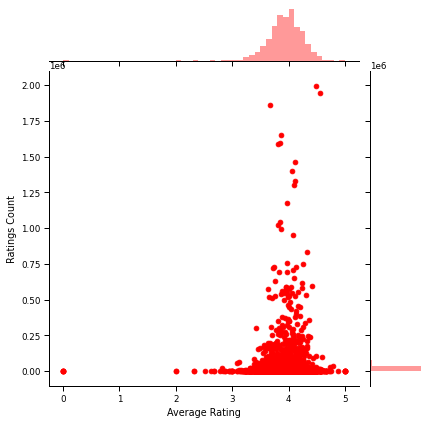

```python
sns.set_context('paper')
ax = sns.jointplot(x="average_rating", y="ratings_count", data = trial, color = 'red')
ax.set_axis_labels("Average Rating", "Ratings Count")
```

we can see that there can be a potential relationship between the average rating and ratings count. As the number of ratings increase, the rating for the book seems to taper towards 4. The average rating seems to become sparse while the number keeps on decreasing.

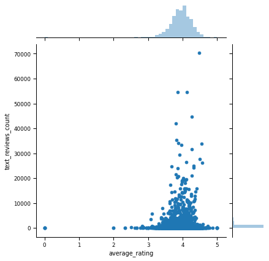

```python
fig=sns.jointplot(x = 'average_rating', y = 'text_reviews_count', data = data, kind='scatter')
```

We can infer from the plot that most of the ratings for the books seems to lie near 3-4, with a heavy amount of reviews lying barely near 5000, approximately. Let's plot that.

```python
trial = data[~(data['text_reviews_count']>5000)]
```

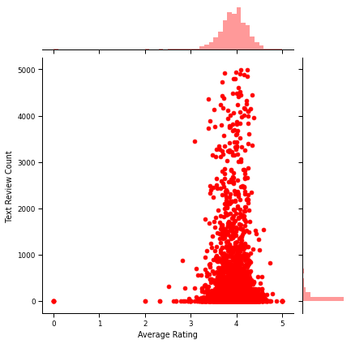

```python
#Checking for any relation between them.
plt.figure(figsize=(15,10))
data.dropna(0, inplace=True)
sns.set_context('paper')
ax =sns.jointplot(x="average_rating",y='text_reviews_count', kind='scatter',  data= trial, color = 'red')
ax.set_axis_labels("Average Rating", "Text Review Count")
plt.show()
```

It can be observed that even now, the majority of text reviews for books still lie under 1000, making this whole scenario inconclusive. There might be a relationship, but the reviews seem to be predominant amongst books with decent ratings

# STEP 4 - DATA MODELLING

```python
data.head()
```

|  | bookID | title | authors | average_rating | isbn | isbn13 | language_code | num_pages | ratings_count | text_reviews_count |
| --- | --- | --- | --- | --- | --- | --- | --- | --- | --- | --- |
| 0 | 1 | Harry Potter and the Half-Blood Prince (Harry ... | J.K. Rowling-Mary GrandPré | 4.56 | 0439785960 | 9780439785969 | eng | 652 | 1944099 | 26249 |
| 1 | 2 | Harry Potter and the Order of the Phoenix (Har... | J.K. Rowling-Mary GrandPré | 4.49 | 0439358078 | 9780439358071 | eng | 870 | 1996446 | 27613 |
| 2 | 3 | Harry Potter and the Sorcerer's Stone (Harry P... | J.K. Rowling-Mary GrandPré | 4.47 | 0439554934 | 9780439554930 | eng | 320 | 5629932 | 70390 |
| 3 | 4 | Harry Potter and the Chamber of Secrets (Harry... | J.K. Rowling | 4.41 | 0439554896 | 9780439554893 | eng | 352 | 6267 | 272 |
| 4 | 5 | Harry Potter and the Prisoner of Azkaban (Harr... | J.K. Rowling-Mary GrandPré | 4.55 | 043965548X | 9780439655484 | eng | 435 | 2149872 | 33964 |

```python
data.columns
```

```
Index(['bookID', 'title', 'authors', 'average_rating', 'isbn', 'isbn13',
       'language_code', 'num_pages', 'ratings_count', 'text_reviews_count'],
      dtype='object')
```

```python
X=data[['bookID', 'title', 'authors', 'isbn', 'isbn13',
       'language_code', 'num_pages', 'ratings_count', 'text_reviews_count']]
```

```python
X.head()
```

|  | bookID | title | authors | isbn | isbn13 | language_code | num_pages | ratings_count | text_reviews_count |
| --- | --- | --- | --- | --- | --- | --- | --- | --- | --- |
| 0 | 1 | Harry Potter and the Half-Blood Prince (Harry ... | J.K. Rowling-Mary GrandPré | 0439785960 | 9780439785969 | eng | 652 | 1944099 | 26249 |
| 1 | 2 | Harry Potter and the Order of the Phoenix (Har... | J.K. Rowling-Mary GrandPré | 0439358078 | 9780439358071 | eng | 870 | 1996446 | 27613 |
| 2 | 3 | Harry Potter and the Sorcerer's Stone (Harry P... | J.K. Rowling-Mary GrandPré | 0439554934 | 9780439554930 | eng | 320 | 5629932 | 70390 |
| 3 | 4 | Harry Potter and the Chamber of Secrets (Harry... | J.K. Rowling | 0439554896 | 9780439554893 | eng | 352 | 6267 | 272 |
| 4 | 5 | Harry Potter and the Prisoner of Azkaban (Harr... | J.K. Rowling-Mary GrandPré | 043965548X | 9780439655484 | eng | 435 | 2149872 | 33964 |

```python
y=data['average_rating']
```

Attributes are the independent variables whilst labels are dependent variables whose values are to be predicted.

```python
# split 80% of the data to the training set and 20% of the data to test set
X_train, X_test, y_train, y_test = train_test_split(X, y, test_size = 0.20, random_state = 10)
```

```python
X=X.drop(['language_code','isbn'],axis=1)
```

```python
X.info()
```

```
<class 'pandas.core.frame.DataFrame'>
Int64Index: 3500 entries, 0 to 3499
Data columns (total 7 columns):
 #   Column              Non-Null Count  Dtype
---  ------              --------------  -----
 0   bookID              3500 non-null   int64
 1   title               3500 non-null   object
 2   authors             3500 non-null   object
 3   isbn13              3500 non-null   int64
 4   num_pages           3500 non-null   int64
 5   ratings_count       3500 non-null   int64
 6   text_reviews_count  3500 non-null   int64
dtypes: int64(5), object(2)
memory usage: 218.8+ KB
```

```python
le = preprocessing.LabelEncoder()
X['title'] = le.fit_transform(X['title'])
```

```python
X['authors'] = le.fit_transform(X['authors'])
```

```python
X.head()
```

|  | bookID | title | authors | isbn13 | num_pages | ratings_count | text_reviews_count |
| --- | --- | --- | --- | --- | --- | --- | --- |
| 0 | 1 | 1022 | 879 | 9780439785969 | 652 | 1944099 | 26249 |
| 1 | 2 | 1023 | 879 | 9780439358071 | 870 | 1996446 | 27613 |
| 2 | 3 | 1025 | 879 | 9780439554930 | 320 | 5629932 | 70390 |
| 3 | 4 | 1021 | 876 | 9780439554893 | 352 | 6267 | 272 |
| 4 | 5 | 1024 | 879 | 9780439655484 | 435 | 2149872 | 33964 |

# STEP 5 - MODEL EVALUATION

# Model 1 : Linear Regression

The aim of this section is to come up with a model for predicting the book ratings. We'll use linear regression to build a model that predicts book ratings.

**Mean Square Error:**

For each point, it calculates square difference between the predictions and the target and then average those values.

**Root Mean Square Error:**

It make scale of the errors to be the same as the scale of targets.

**Mean Absolute Error:**

Average of absolute differences between the target values and the predictions.

*Linear Regression with different features.*

```python
# split 80% of the data to the training set and 20% of the data to test set
X_train, X_test, y_train, y_test = train_test_split(X, y, test_size = 0.20, random_state = 10)
```

```python
regr = linear_model.LinearRegression()
y_train = y_train[:, np.newaxis]
regr.fit(X_train, y_train)
```

```
LinearRegression(copy_X=True, fit_intercept=True, n_jobs=None, normalize=False)
```

```python
print(X_train.shape)
print(y_train.shape)
print(X_test.shape)
print(y_test.shape)
```

```
(2800, 7)
(2800, 1)
(700, 7)
(700,)
```

Metrics evaluation

Use the test data to check accurately our algorithm predicts the percentage score.

```python
y_predict = regr.predict(X_test)
print("Accuracy of Linear Regressor (Mean squared error): ",mean_squared_error(y_predict,y_test))
```

```
Accuracy of Linear Regressor (Mean squared error):  0.1263480632366212
```

```python
print("Root mean square error: ",np.sqrt(mean_squared_error(y_test,y_predict)))
```

```
Root mean square error:  0.35545472740789535
```

```python
print("Mean absolute error: ",mean_absolute_error(y_test, y_predict))
```

```
Mean absolute error:  0.2313850442666012
```

```python
X.head()
```

|  | bookID | title | authors | isbn13 | num_pages | ratings_count | text_reviews_count |
| --- | --- | --- | --- | --- | --- | --- | --- |
| 0 | 1 | 1022 | 879 | 9780439785969 | 652 | 1944099 | 26249 |
| 1 | 2 | 1023 | 879 | 9780439358071 | 870 | 1996446 | 27613 |
| 2 | 3 | 1025 | 879 | 9780439554930 | 320 | 5629932 | 70390 |
| 3 | 4 | 1021 | 876 | 9780439554893 | 352 | 6267 | 272 |
| 4 | 5 | 1024 | 879 | 9780439655484 | 435 | 2149872 | 33964 |

```python
#compare the actual output values for X_test with the predicted values.
pred = pd.DataFrame({'Actual': y_test.tolist(), 'Predicted': y_predict.tolist()}).head(25)
pred.head(10)
```

|  | Actual | Predicted |
| --- | --- | --- |
| 0 | 3.67 | [3.9248643251879725] |
| 1 | 3.91 | [3.965177583597351] |
| 2 | 4.15 | [3.9108096684760203] |
| 3 | 3.48 | [3.9215116680829274] |
| 4 | 4.09 | [3.913265631262017] |
| 5 | 4.36 | [3.9841161014053177] |
| 6 | 3.85 | [3.891439011965505] |
| 7 | 4.06 | [3.960699865276683] |
| 8 | 4.16 | [3.92764365112342] |
| 9 | 4.62 | [3.962279694186358] |

*Linear regression by dropping few features.*

```python
X1=X.drop(['isbn13'],axis=1)
```

```python
X_train1, X_test1, y_train1, y_test1 = train_test_split(X1, y, test_size = 0.20, random_state = 10)
```

```python
regr = linear_model.LinearRegression()
y_train1 = y_train1[:, np.newaxis]
regr.fit(X_train1, y_train1)
```

```
LinearRegression(copy_X=True, fit_intercept=True, n_jobs=None, normalize=False)
```

Metrics evaluation

```python
y_predict1 = regr.predict(X_test1)
print("Accuracy of Linear Regressor (Mean squared error)",mean_squared_error(y_test1,y_predict1))
```

```
Accuracy of Linear Regressor (Mean squared error) 0.12638245557945246
```

```python
print("Root mean square error: ",np.sqrt(mean_squared_error(y_test,y_predict1)))
```

```
Root mean square error:  0.3555031020672709
```

```python
print("Mean absolute error",mean_absolute_error(y_test1, y_predict1))
```

```
Mean absolute error 0.23136498755980062
```

```python
X1.head()
```

|  | bookID | title | authors | num_pages | ratings_count | text_reviews_count |
| --- | --- | --- | --- | --- | --- | --- |
| 0 | 1 | 1022 | 879 | 652 | 1944099 | 26249 |
| 1 | 2 | 1023 | 879 | 870 | 1996446 | 27613 |
| 2 | 3 | 1025 | 879 | 320 | 5629932 | 70390 |
| 3 | 4 | 1021 | 876 | 352 | 6267 | 272 |
| 4 | 5 | 1024 | 879 | 435 | 2149872 | 33964 |

```python
#compare the actual output values for X_test with the predicted values.
pred = pd.DataFrame({'Actual': y_test1.tolist(), 'Predicted': y_predict1.tolist()}).head(25)
pred.head(10)
```

|  | Actual | Predicted |
| --- | --- | --- |
| 0 | 3.67 | [3.9248478440815355] |
| 1 | 3.91 | [3.965175793653809] |
| 2 | 4.15 | [3.910798783046668] |
| 3 | 3.48 | [3.92148377358781] |
| 4 | 4.09 | [3.9132290007136237] |
| 5 | 4.36 | [3.9841157443545807] |
| 6 | 3.85 | [3.8914118726740177] |
| 7 | 4.06 | [3.960671808981202] |
| 8 | 4.16 | [3.927617060462405] |
| 9 | 4.62 | [3.962258174114922] |

# Model 2 : Random Forest

**Random Forest Regressor:**

Meta estimator that fits a number of classifying decision trees on various sub-samples of the dataset.

Averaging to improve the predictive accuracy and control over-fitting.

```python
from sklearn.ensemble import RandomForestRegressor
model = RandomForestRegressor(n_estimators=150,n_jobs=-1,min_samples_leaf=5, max_features=0.5)
model.fit(X_train,y_train)
```

```
RandomForestRegressor(bootstrap=True, ccp_alpha=0.0, criterion='mse',
                      max_depth=None, max_features=0.5, max_leaf_nodes=None,
                      max_samples=None, min_impurity_decrease=0.0,
                      min_impurity_split=None, min_samples_leaf=5,
                      min_samples_split=2, min_weight_fraction_leaf=0.0,
                      n_estimators=150, n_jobs=-1, oob_score=False,
                      random_state=None, verbose=0, warm_start=False)
```

```python
predict_test= model.predict(X_test)
```

```python
print('Accuracy score of Random Forest model',model.score(X_test,y_test))
```

```
Accuracy score of Random Forest model 0.19103546697997198
```

Model 1: Linear Regressor

Model 2: Random Forest Regressor